[figure not shown]

MODELOS DE ECUACIONES

ESTRUCTURALES Gabriel Sotomayor

CONTENIDOS

•Trabajo Final e Inscripción de grupos

•Pruebas atrasadas

•Introducción a los modelos de ecuaciones estructurales

[figure not shown]

TRABAJO FINAL

La evaluación final consta de un breve trabajo de investigación en que se utilice un

modelo factorial confirmatorio, de senderos o de ecuaciones estructurales.

Debe realizarse en grupos de 3 estudiantes. Debe inscribirse en el siguiente enlace:

https://docs.google.com/spreadsheets/d/1n2VSGYNht86FgjlxUAyufamBNXWSc0ro

lIOEr0Qau-Q/edit?gid=0#gid=0

Se entrega el lunes 1 de Julio (fecha no modificable por fin de semestre).

Debe incluir: Breve planteamiento del problema y antecedentes, metodología,

análisis estadístico y conclusiones.

PRUEBAS ATRASADAS

Se fijará una fecha para tomar las pruebas pendientes la próxima semana.

[figure not shown]

MODELOS DE ECUACIONES

ESTRUCTURALES

[figure not shown]

INTRODUCCIÓN A LOS MODELOS

DE ECUACIONES ESTRUCTURALES

Los Modelos de Ecuaciones Estructurales son una familia de modelos estadísticos

multivariantes que permiten estimar el efecto y las relaciones entre múltiples

variables. Nacieron de la necesidad de dar mayor flexibilidad a los modelos de

regresión y son menos restrictivos al permitir incluir errores de medida tanto en

variables dependientes como independientes.

También se les conoce como modelos SEM (Structural Equation Models).

LOS MODELOS DE ECUACIONES

ESTRUCTURALES

•Estos modelos permiten proponer el tipo y dirección de las relaciones entre las

variables contenidas en él, y estimar los parámetros que vienen especificados por

las relaciones propuestas a nivel teórico.

•Se les denomina también modelos confirmatorios, ya que el interés fundamental es

“confirmar” mediante el análisis de la muestra las relaciones propuestas a partir de

la teoría explicativa que se haya decidido utilizar como referencia.

•Para su estimación, se basan en las correlaciones existentes entre las variables

medidas en una muestra de sujetos de manera transversal. Las variables deben ser

cuantitativas, preferentemente continuas.

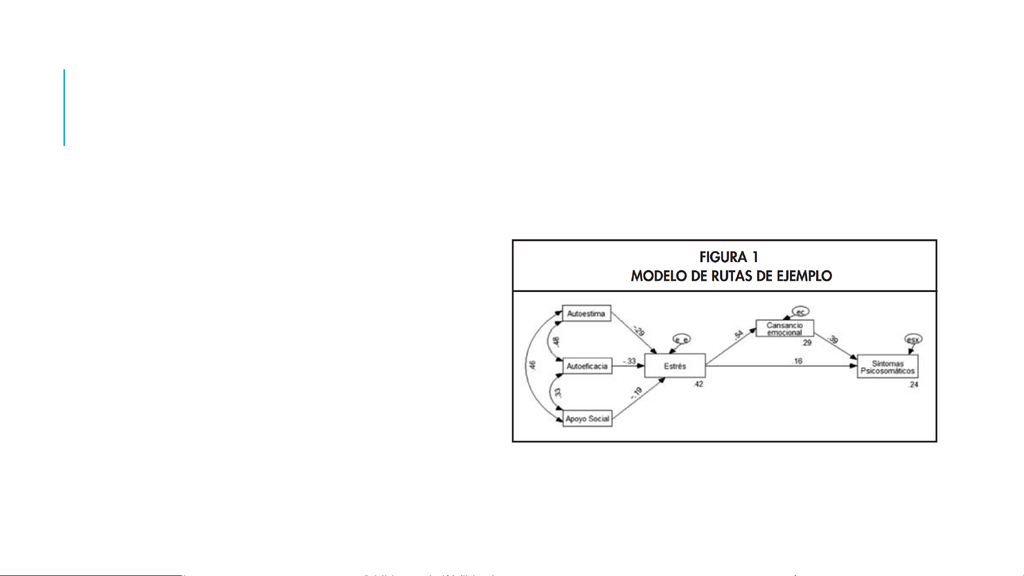

LOS MODELOS DE ECUACIONES

ESTRUCTURALES

Ejemplo de aplicación en el campo de la

salud: Modelo de análisis de rutas que

predice la magnitud de los síntomas

psicosomáticos de una persona a partir de

un conjunto de antecedentes personales

(autoestima, autoeficacia, apoyo social,

nivel de estrés, etc.)

La interpretación de los parámetros

estimados permite constatar las relaciones

entre las variables. Por ejemplo, las

variables predictoras pueden tener un

efecto negativo sobre el nivel de estrés, y la

autoeficacia percibida puede ser el

predictor con mayor efecto.

SEM Y CAUSALIDAD

1.Estimación y Causalidad: Aunque los modelos permiten representar gráficamente

la influencia causal, la estimación de un parámetro no "demuestra" la existencia de

causalidad. La causalidad debe venir sustentada por la teoría del modelo, y con

datos y técnicas que permitan contrastar casualidad.

2.Verificación de Teorías: Si la teoría es correcta, las medidas de covariación

derivadas del modelo y las medidas de covariación obtenidas a partir de los datos

deberán ser iguales. Esto proporciona una base para la comprobación de teorías o

modelos relacionales.

ESTRUCTURA DE UN MODELO DE

ECUACIONES ESTRUCTURALES

1.Modelo de Medida: Define cómo cada constructo latente se mide mediante

indicadores observables, los errores que afectan las mediciones, y las relaciones

esperadas entre los constructos.

2.Modelo de Relaciones Estructurales: Contiene los efectos y relaciones entre los

constructos (normalmente variables latentes). Similar a un modelo de regresión,

pero puede contener efectos concatenados, como en el análisis de senderos.

Permite evaluar si se relacionan según el modelo teórico propuesto.

3.Casos Excepcionales:

1. Análisis Factorial Confirmatorio: Solo contiene el modelo de medida. Las relaciones entre las

variables latentes solo pueden ser correlacionales.

2. Análisis de Senderos: No contiene variables latentes. Las variables observables se equiparán con

las latentes, existiendo solo el modelo de relaciones estructurales. Los errores de medición y

predicción se confunden en un término común.

TIPOS DE VARIABLES EN UN

MODELO ESTRUCTURAL

1.Variable Observada o Indicador: Las variables que se miden en los sujetos, como las

preguntas de un cuestionario.

2.Variable Latente: Características deseadas para medir que no se pueden observar

directamente y que están libres de errores de medición. Ejemplo: una dimensión de un

cuestionario.

3.Variable Error: Representa los errores asociados con la medición de una variable y el

conjunto de variables no consideradas en el modelo que pueden afectar la medición de una

variable observada. Son consideradas latentes ya que no son observables directamente.

4.Variable Exógena: Variables que afectan a otras variables pero que no reciben el efecto de

ninguna otra. Las variables independientes en un modelo de regresión son exógenas.

5.Variable Endógena: Variable que recibe el efecto de otra variable. La variable dependiente

de un modelo de regresión es endógena. Cada variable endógena debe estar acompañada

de un error.

DIAGRAMAS ESTRUCTURALES -

CONVENCIONES Y DEFINICIONES

1.Diagramas Estructurales: Estos son herramientas gráficas utilizadas para

representar modelos causales y las relaciones deseadas dentro de ellos. Son

similares a los diagramas de flujo y ayudan en la especificación de modelos y

parámetros.

2.Representación de Variables:

1. Variables Observables: Estas son las variables que se pueden medir directamente. En los

diagramas estructurales, se representan encerradas en rectángulos.

2. Variables No Observables (Latentes): Estas son las variables que deseamos medir pero no se

pueden observar directamente. En los diagramas, se representan en óvalos o círculos.

3. Errores: Estos representan los errores asociados con la medición de una variable y se

representan sin rectángulos ni círculos.

DIAGRAMAS ESTRUCTURALES -

CONVENCIONES Y DEFINICIONES

1.Representación de Relaciones:

1. Relaciones Bidireccionales: Estas implican correlaciones y covarianzas, y se representan como

vectores curvos con una flecha en cada extremo. Puede ir entre variables latentes o entre

términos de error de variables endógenas.

2. Efectos Estructurales: Cualquier efecto estructural se representa como una flecha recta. El

origen de la flecha es la variable predictora y el final es la variable dependiente.

3. Parámetros del Modelo: Los parámetros de un modelo se representan sobre la flecha

correspondiente a la relación que representan.

2.Término Error: Cualquier variable que recibe efecto de otras variables del modelo

deberá incluir también un término error. Esto permite el manejo del error en la

predicción del modelo.

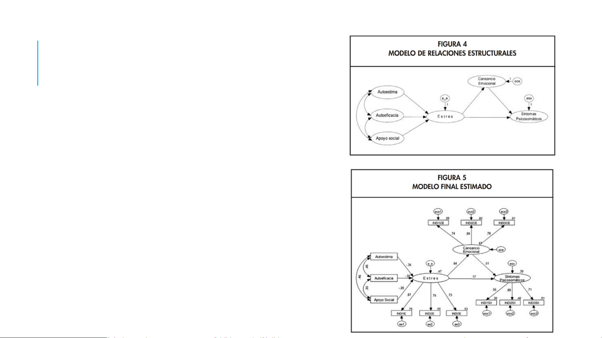

EJEMPLO

•Modelo que contiene seis variables latentes:

autoestima, autoeficacia, apoyo social, estrés,

cansancio emocional y síntomas psicosomáticos.

•Tres primeras variables latentes son exógenas y las

tres últimas son endógenas.

•Cada variable latente endógena está medida

mediante tres variables observables o indicadores.

•Modelo final estimado: Variables exógenas son

utilizadas para predecir el nivel de estrés.

•Los efectos directos y indirectos entre variables.

•Efecto total de una variable: suma del efecto

directo y el efecto indirecto a través de otras

variables.

TIPOS DE RELACIONES EN MODELOS

DE ECUACIONES ESTRUCTURALES

Los modelos de ecuaciones estructurales nos permiten explorar diferentes tipos de

relaciones entre variables. Examinaremos los siguientes tipos:

1.Covariación vs Causalidad

2.Relación Espuria

3.Relación “Causal”Directa e Indirecta

4.Relación “Causal”Recíproca

5.Efectos Totales

COVARIACIÓN, CAUSALIDAD Y

RELACIÓN ESPURIA

•Covariación se refiere a cuando dos fenómenos cambian juntos, pero no

necesariamente significa que uno cause el otro.

•Causalidad se refiere a un cambio en una variable que provoca un cambio en otra.

•Una Relación Espuria ocurre cuando la relación entre dos variables es causada, total

o parcialmente, por su relación común con una tercera variable, como la relación

entre estatura e inteligencia en preescolares, donde la edad es la variable común.

RELACIONES CAUSALES: DIRECTAS,

INDIRECTAS Y RECÍPROCAS

•Relación Causal Directa: Un cambio en una variable causa un cambio en otra.

•Relación Causal Indirecta: La presencia de una tercera variable que modula o media

el efecto entre las dos primeras. Por ejemplo, la motivación puede modular la

relación entre la aptitud y el rendimiento.

•Relación Causal Recíproca: La variable causa es a su vez efecto de la otra. Por

ejemplo, mayor ansiedad puede llevar a un peor rendimiento académico, y a su vez,

un peor rendimiento puede incrementar la ansiedad. Para poder incluirse en el

modelo se requiere contar con una dimensión temporal.

EFECTOS NO ANALIZADOS

•Son las posibles relaciones representadas por flechas que podrían estar presentes en el

modelo, pero no lo están.

•Puede ser debido a errores de especificación, donde se han dejado fuera variables

importantes.

•También podría ser debido a la suposición de que las variables no consideradas en el

modelo se equilibran entre sí, incorporando su efecto en los términos de error del modelo.

•A la suma de los efectos espurios más los efectos no analizados se les denomina efectos no

causales.

•Una vez que el modelo está definido, los efectos espurios aparecen cuando las variables

endógenas están correlacionadas más allá de los efectos estimados (apareciendo covarianzas

entre los errores de predicción). Los efectos no analizados aparecen cuando las variables

observables están correlacionadas más allá de lo que el modelo predice (apareciendo

covarianzas entre los errores de medición)

SUPUESTOS DE LOS MODELO DE ECUACIONES

ESTRUCTURALES.

Tamaño de muestra suficientemente grande: al menos 200, además de un cierto

mínimo por parámetro (20 casos).

Relaciones lineales entre las variables.

Normalidad multivariante (importante para el método de estimación).

Identificación del modelo.

Ausencia de multicolinealidad.

Variables continuas (aunque puede adaptarse a variables nominales)-

[figure not shown]

PASOS DE UN MODELO DE

ECUACIONES ESTRUCTURALES

PASO 1: ESPECIFICACIÓN DEL

MODELO

1.La teoría que respalda el modelo debe estar formulada de tal manera que pueda

ser probada con datos reales. Debe incluir las variables consideradas importantes y

que deben ser medidas.

2.Especificar las relaciones esperadas entre las variables: correlaciones, efectos

directos, efectos indirectos. Si una variable no es observable directamente, deben

identificarse los indicadores que permiten medirla.

3.Formular el modelo teórico en formato gráfico. Esto permite identificar fácilmente

las ecuaciones y parámetros.

PASO 2: IDENTIFICACIÓN DEL

MODELO

Al igual que en el análisis de senderos debemos asegurarnos que contamos con

información suficiente para estimar el modelo (Relación entre cantidad de variables

y parámetros a estimar).

Cada parámetro debe estar correctamente identificado y ser derivable de la

información en la matriz de varianzas-covarianzas.

Debemos revisar que los grados de libertad sean mayores a 0.

Estrategias para garantizar que todos los parámetros estén identificados: usar al

menos tres indicadores por variable latente, igualar la métrica de cada variable

latente con uno de sus indicadores.

PASO 3: ESTIMACIÓN DEL

MODELO

1.Debe estimarse los parámetros del modelo a partir del modelo especificado.

2.El método por defecto es máxima verosimilitud, aunque hay otros disponibles en el

paquete Lavaan de R.

PASO 4: EVALUACIÓN DE AJUSTE

1.Valorar el ajuste del modelo. Si las estimaciones obtenidas no reproducen

correctamente los datos observados, será necesario rechazar el modelo y/o

reformularlo.

2.En los modelos de ecuaciones estructurales un buen ajuste requiere que tanto el

modelo de medición como el modelo de relaciones entre variables se ajusten a los

datos observados (más difícil aún).

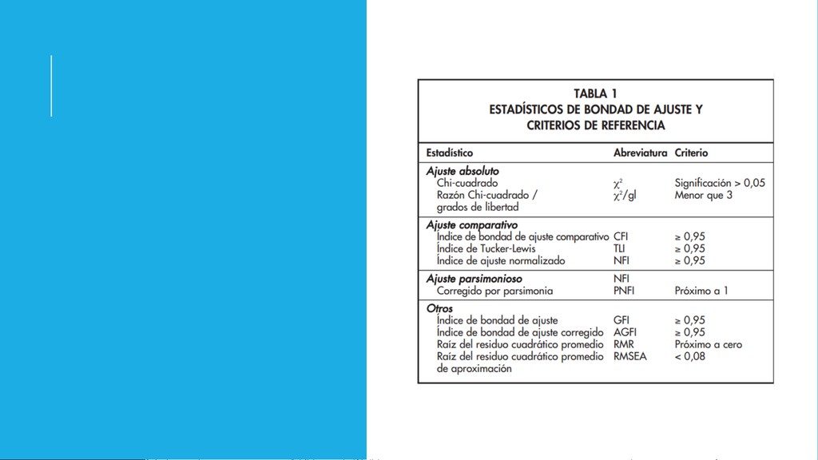

ESTADÍSTICOS DE

BONDAD DE

AJUSTE

Existen tres tipos de estadísticos de

bondad de ajuste:

Ajuste Absoluto: Valoran los residuos

del modelo.

Ajuste Relativo: Comparan el ajuste

del modelo con otro de peor ajuste.

Ajuste Parsimonioso: Evalúan el ajuste

respecto al número de parámetros

utilizados en el modelo.

Ninguno de estos estadísticos

proporciona toda la información

necesaria para evaluar un modelo,

por lo que generalmente se usa un

conjunto de ellos simultáneamente

CHI CUADRADO

•Es conceptualmente el más atractivo, ya que permite contrastar la hipótesis nula de

que todos los errores del modelo son nulos.

•Sin embargo, es muy sensible al tamaño de la muestra: con muestras grandes

(mayores de 100 o 200 casos) es relativamente fácil rechazar la hipótesis nula, incluso

cuando el modelo tiene un buen ajuste.

•Siempre se informa este estadístico.

PASO 5: RE-

ESPECIFICACIÓN

Luego de ajustar el modelo, especialmente si este

presenta un ajuste insatisfactorio, pueden

introducirse modificaciones al modelo (agregar o

quitar parámetros).

Para esto debemos evaluar los cambios que

pueden mejorar el modelo, a partir de los índices

de modificación.

Los cambios propuestos deben ser coherentes con

la teoría.

PASO 6: INTERPRETACIÓN DE RESULTADOS

Coeficientes Beta Estandarizados: Se refieren al impacto que resulta de un incremento de una

desviación estándar en la variable independiente sobre la variable dependiente, expresada también en

términos de desviación estándar. Esto se realiza teniendo en cuenta las demás variables presentes en

el modelo.

Significación de cada coeficiente: Si obtenemos un valor de p menor a 0,05, desechamos la hipótesis

nula que propone que el coeficiente beta es igual a cero. Esto nos da una confianza del 95% en nuestra

conclusión.

R-cuadrado: Representa el porcentaje de la varianza en la variable dependiente que puede ser

explicado por el modelo de ecuaciones estructurales. Es decir, cuánta variabilidad en los datos puede

ser descrita por el modelo.

Atención: Los coeficientes no solo describen el modelo de medición, sino también el modelo de

relaciones entre las variables. Esto significa que en los modelos de ecuaciones estructurales, los

coeficientes también nos indican cómo las variables medidas se relacionan entre sí, y cómo estas

relaciones dan forma a las variables dependientes que estamos investigando. Es crucial tener en

cuenta este doble papel al interpretar los resultados de un modelo de ecuaciones estructurales.